# Project 2 - Phase 1

# What is the average time of interaction with a given machine

First we found average duration of visitors’ activities and the number of visitors in every station.

```r
avgData = mergedData %>%
group_by(station) %>%
summarise(avgTime = median(time),
          visitorCount = n())
avgData
```

```
## Source: local data frame [9 x 3]
##
##   station avgTime visitorCount
##    (fctr)   (dbl)        (int)
## 1   cnk05      64        14677
## 2   cnk10      60        16444
## 3   cnk18      62        18600
## 4  cnk19a      28        27289
## 5   cnk20      93        14675
## 6   cnk38     142         7237
## 7   cnk56      96         9054
## 8   cnk61      63        12229
## 9   cnk66      95        14280
```

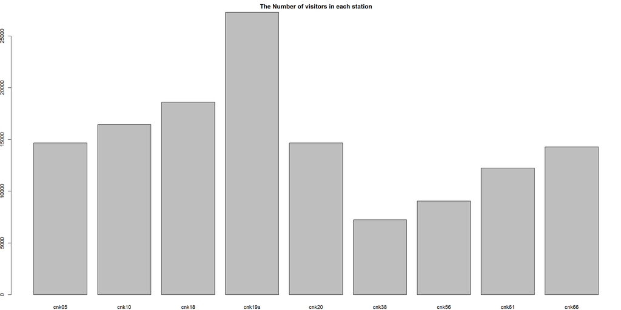

```r
par(mar=c(2,1.8,2,0))
barplot(c(avgData$visitorCount), main="The Number of visitors in each station", xlab="Stations", ylab = "Number of visitors", names.arg=as.character(avgData$station))
```

```r
# Distribution of the number of visitors per station
summary(avgData$visitorCount)
```

```
##    Min. 1st Qu.  Median    Mean 3rd Qu.    Max.
##    7237   12230   14680   14940   16440   27290
```

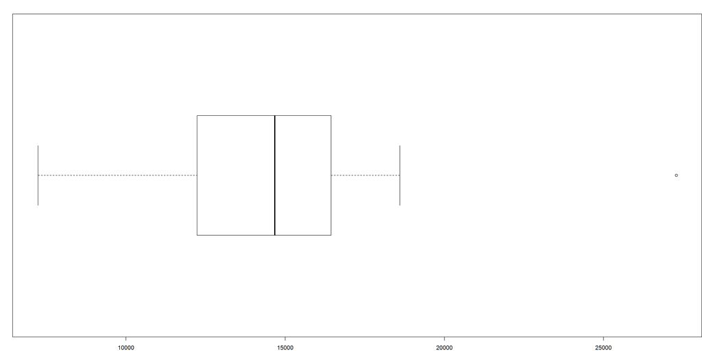

```r
# Boxplot of count
boxplot(avgData$visitorCount, horizontal = TRUE)
```

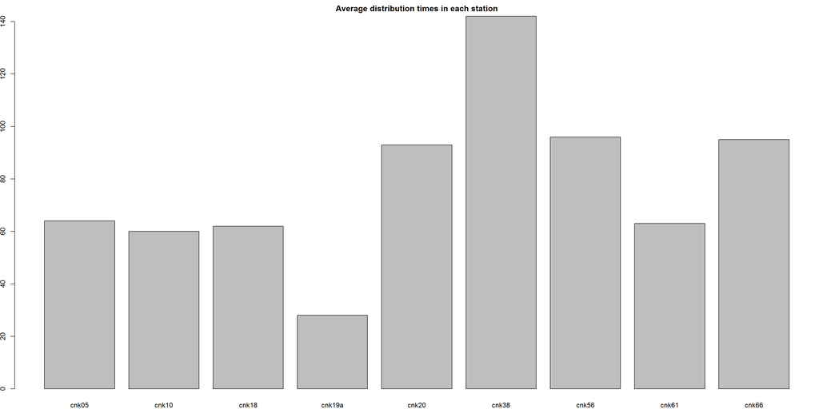

```r
par(mar=c(2,1.8,2,0))
barplot(c(avgData$avgTime), main="Average distribution times in each station", xlab="Stations", ylab = "Time[s]",names.arg=as.character(avgData$station))
```

```r
# Distribution of time per station
summary(avgData$avgTime)
```

```
##    Min. 1st Qu.  Median    Mean 3rd Qu.    Max.
##   28.00   62.00   64.00   78.11   95.00  142.00
```

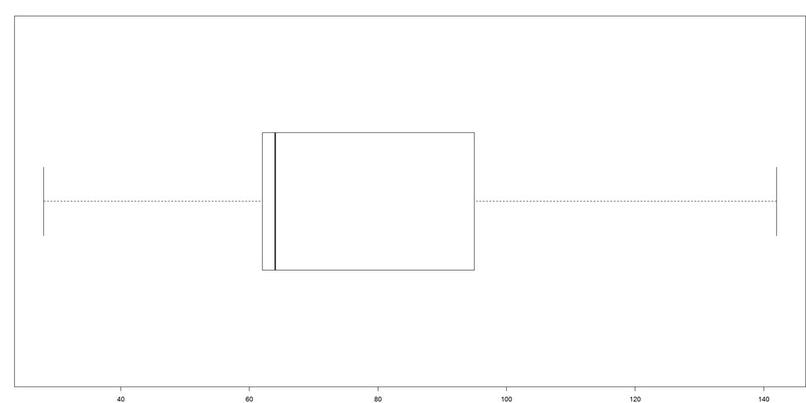

```r
# Boxplot of time
boxplot(avgData$avgTime, horizontal = TRUE)
```

The station in which visitors spent definitely the most time is cnk38, therefore the least number of visitors played with it. With cnk19a visitors spent the least time per visit so the biggest amount of visitors had chance to play with it.

# Is there a relation between the duration of an interaction and variables like weekday or hour?

Then we check if there is a dependence between the duration of an interaction and weekday and hour.

## Weekday

```r
weekdayStationData = mergedData %>%
group_by(station, weekday) %>%
summarise(avgTime = median(time),
          visitorCount = n())
weekdayStationData = as.data.frame(weekdayStationData)

# Average time spent per station per day

stationDayTimeTab = cast(weekdayStationData, station ~ weekday, value="avgTime")
stationDayTimeTab
```

```
##   station Sunday Monday Tuesday Wednesday Thursday Friday Saturday
## 1   cnk05   70.0  144.5      61        62       60     63       68
## 2   cnk10   73.0  213.0      55        53       53     58       69
## 3   cnk18   66.0  179.0      60        58       60     60       65
## 4  cnk19a   29.0   52.5      27        28       27     28       28
## 5   cnk20   99.0  139.0      90        90       91     92       98
## 6   cnk38  149.0   96.0     138       139      137    139      151
## 7   cnk56  105.0     NA      91        91       88     95      104
## 8   cnk61   79.5   84.0      56        56       56     60       78
## 9   cnk66  100.0   50.0      90        91       90     94      101
```

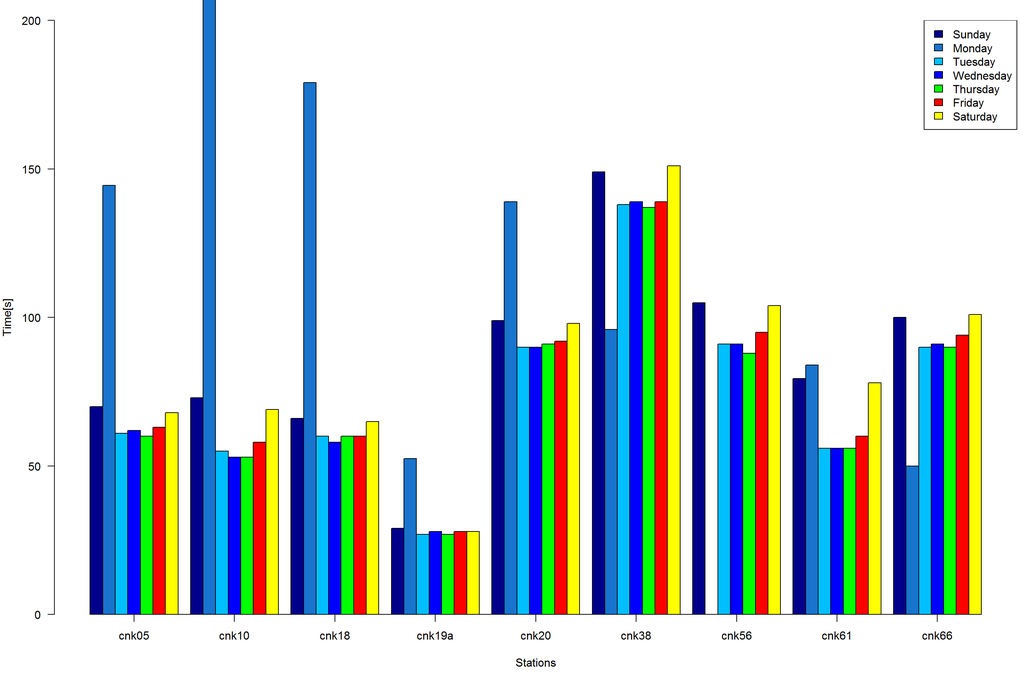

```r
par(mar = c(5, 4, 1.5, 0.5), ps = 12, cex  = 1, cex.main = 2, las = 1)
barplot(
  t(as.matrix(stationDayTimeTab)),
  beside      = TRUE,
  ylim        = c(0,200),
  xlab        = "Stations",
  ylab        = "Time[s]",
  axes        = TRUE,
  axis.lty    = 1,
  col         = c("darkblue", "dodgerblue3", "deepskyblue1", "blue", "green", "red", "yellow"),
  panel.first =  abline(
    h    =  seq.int(25, 100, 25),
    col  =  "grey",
    lty  =  2
  )
)

legend("topright",
       legend = c("Sunday",  "Monday", "Tuesday", "Wednesday", "Thursday", "Friday", "Saturday"),
       fill = c("darkblue", "dodgerblue3", "deepskyblue1", "blue", "green", "red", "yellow"))
```

```r
# The number of visitors per station per day

stationDayVisitorCountTab = cast(weekdayStationData, station ~ weekday, value="visitorCount")
stationDayVisitorCountTab
```

```
##   station Sunday Monday Tuesday Wednesday Thursday Friday Saturday
## 1   cnk05   2465      4    2315      2216     2379   2600     2698
## 2   cnk10   2573      3    2665      2568     2789   2929     2917
## 3   cnk18   3000      4    3008      2953     3086   3312     3237
## 4  cnk19a   4533      2    4267      4120     4493   4828     5046
## 5   cnk20   2383      3    2362      2327     2443   2589     2568
## 6   cnk38   1182      1    1164      1135     1216   1277     1262
## 7   cnk56   1476     NA    1492      1484     1451   1582     1569
## 8   cnk61   1816      1    2039      2002     2190   2158     2023
## 9   cnk66   2342      3    2313      2277     2390   2484     2471
```

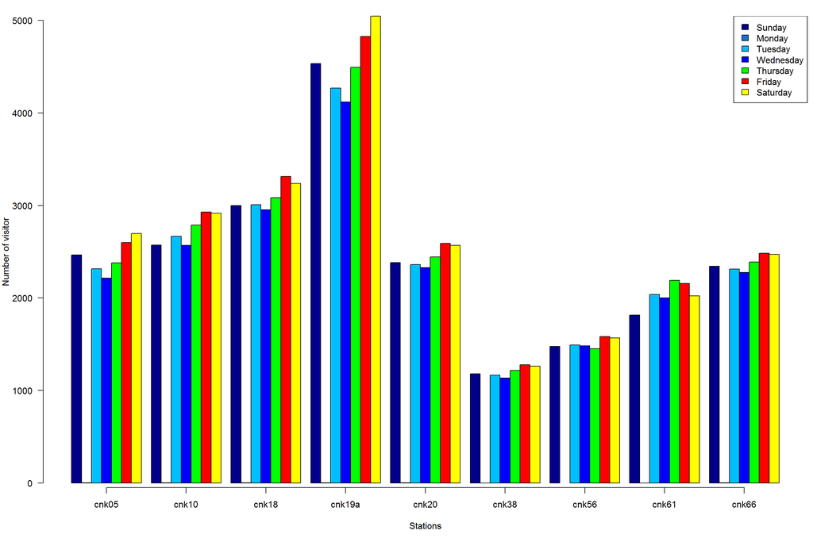

```r
par(mar = c(5, 4, 1.5, 0.5), ps = 12, cex  = 1, cex.main = 2, las = 1)
barplot(
  t(as.matrix(stationDayVisitorCountTab)),
  beside      = TRUE,
  xlab        = "Stations",
  ylab        = "Number of visitor",
  axes        = TRUE,
  axis.lty    = 1,
  col         = c("darkblue", "dodgerblue3", "deepskyblue1", "blue", "green", "red", "yellow"),
  panel.first =  abline(
    h    =  seq.int(25, 100, 25),
    col  =  "grey",
    lty  =  2
  )
)

legend("topright",
       legend = c("Sunday",  "Monday", "Tuesday", "Wednesday", "Thursday", "Friday", "Saturday"),
       fill = c("darkblue", "dodgerblue3", "deepskyblue1", "blue", "green", "red", "yellow"))
```

```r
weekdayGeneralData = mergedData %>%
group_by(weekday) %>%
summarise(avgTime = median(time),
          visitorCount = n())
weekdayGeneralData
```

```
## Source: local data frame [7 x 3]
##
##     weekday avgTime visitorCount
##      (fctr)   (dbl)        (int)
## 1    Sunday      73        21770
## 2    Monday      84           21
## 3   Tuesday      61        21625
## 4 Wednesday      61        21082
## 5  Thursday      61        22437
## 6    Friday      63        23759
## 7  Saturday      71        23791
```

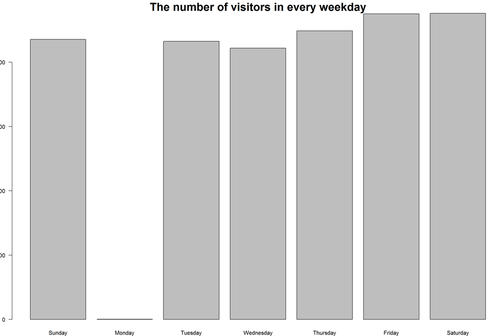

```r
par(mar=c(2,1.8,2,0))

# Barplot of the number of visitors per weekday
barplot(c(weekdayGeneralData$visitorCount), main="The number of visitors in every weekday", xlab="Weekdays", ylab = "Number of visitors",names.arg=as.character(weekdayGeneralData$weekday))
```

```r
# Distribution of the number of visitors per weekday
summary(weekdayGeneralData$visitorCount)
```

```
##    Min. 1st Qu.  Median    Mean 3rd Qu.    Max.
##      21   21350   21770   19210   23100   23790
```

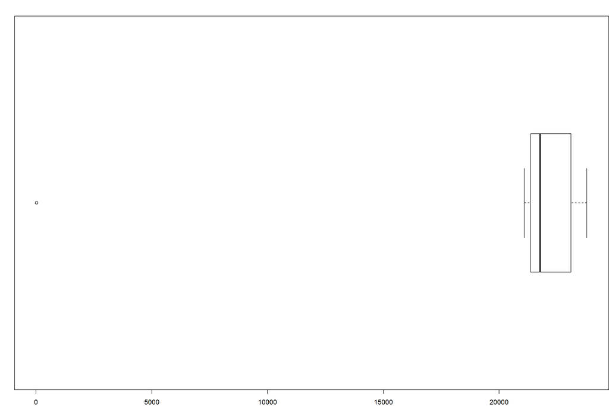

```r
# Boxplot of the number of visitors per weekday
boxplot(weekdayGeneralData$visitorCount, horizontal = TRUE)
```

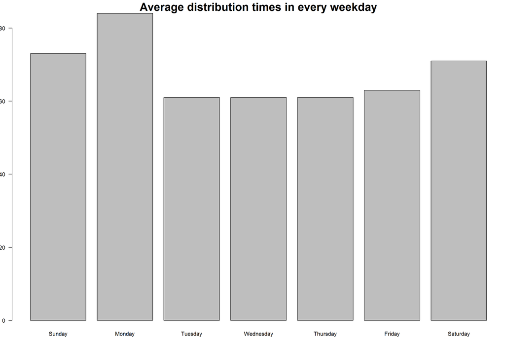

```r
# Widać, że w poniedziałki super mało wizyt - tylko konserwacyjne prace

# Barplot of time per weekday
barplot(c(weekdayGeneralData$avgTime), main="Average distribution times in every weekday", xlab="Weekdays",ylab = "Time[s]", names.arg=as.character(weekdayGeneralData$weekday))
```

```r
# Distribution of time per weekday
summary(weekdayGeneralData$avgTime)
```

```
##    Min. 1st Qu.  Median    Mean 3rd Qu.    Max.
##   61.00   61.00   63.00   67.71   72.00   84.00
```

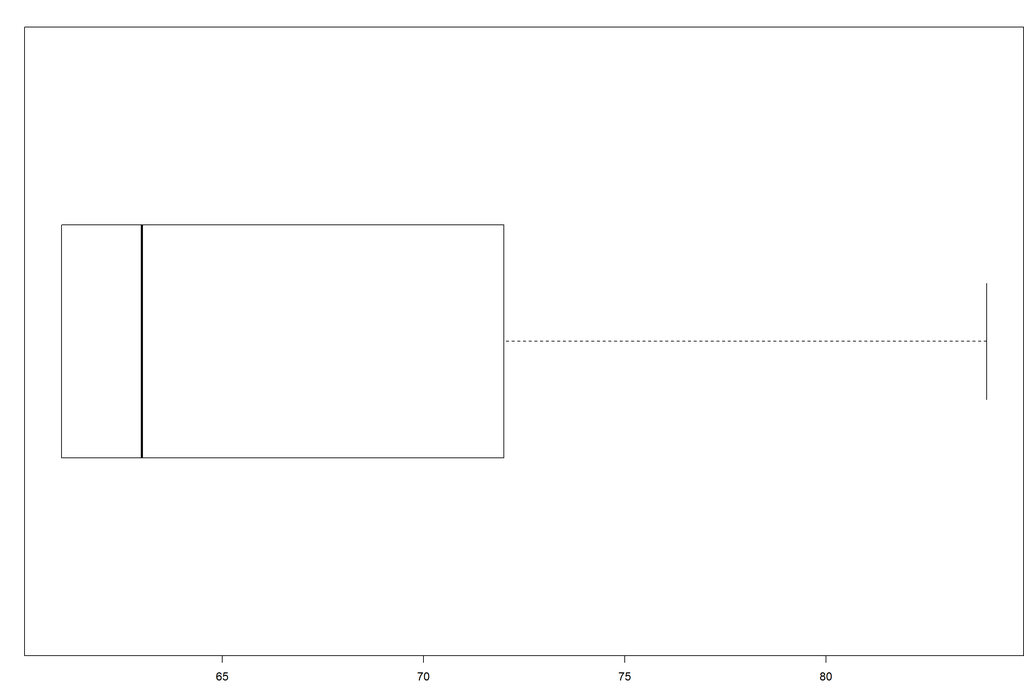

```r
# Boxplot of time per weekday
boxplot(weekdayGeneralData$avgTime, horizontal = TRUE)
```

The average time spent in the stations and the number of visitors during different days of the week were quite similar. The only exception is Monday. Probably during Mondays stations are closed and the only activity with them is maintenance which takes more time than average visitor’s activity.

## Hour

```r
hourStationData = mergedData %>%
group_by(station, hour) %>%
summarise(avgTime = median(time),
          visitorCount = n())
hourStationData = as.data.frame(hourStationData)

# Average time spent per station per hour

stationHourTimeTab = cast(hourStationData, station ~ hour, value="avgTime")
stationHourTimeTab
```

```
##   station 08    09  10  11  12  13  14    15  16  17    18    19    20
## 1   cnk05 NA  61.0  60  63  65  66  64  66.0  64  63  60.0  59.0 112.0
## 2   cnk10 NA  39.5  50  59  63  64  63  61.0  59  60  61.0  72.5  38.0
## 3   cnk18 NA  53.5  57  60  62  62  63  62.0  61  62  67.0  42.0 229.0
## 4  cnk19a 30  31.0  33  28  27  28  28  27.0  27  30  32.0  53.0  45.0
## 5   cnk20 NA  86.0  88  91  94  94  94  95.0  93  97  99.0  52.0  90.0
## 6   cnk38 NA 119.0 126 140 141 147 145 144.0 143 140 145.0 181.0    NA
## 7   cnk56 36  64.0  79  85  98  99 107  92.5  99 102  93.0  75.5 163.0
## 8   cnk61 38  37.0  48  55  63  66  67  67.0  63  67  80.5  42.5  47.0
## 9   cnk66 NA  87.0  89  92  95  97  96  96.0  94  95 101.0  66.0  79.5
##      21
## 1    NA
## 2  51.0
## 3  80.5
## 4  66.5
## 5    NA
## 6 156.5
## 7  33.0
## 8  84.0
## 9    NA
```

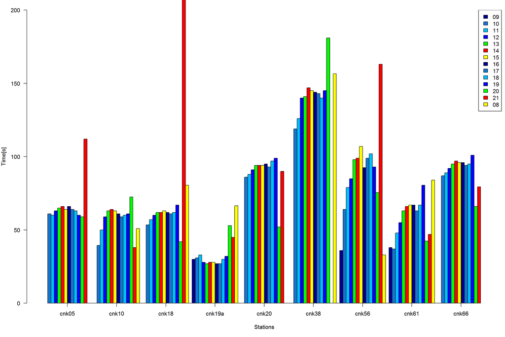

```r
par(mar = c(5, 4, 1.5, 0.5), ps = 12, cex  = 1, cex.main = 2, las = 1)
barplot(
  t(as.matrix(stationHourTimeTab)),
  beside      = TRUE,
  ylim        = c(0,200),
  xlab        = "Stations",
  ylab        = "Time[s]",
  axes        = TRUE,
  axis.lty    = 1,
  col         = c("darkblue", "dodgerblue3", "deepskyblue1", "blue", "green", "red", "yellow"),
  panel.first =  abline(
    h    =  seq.int(25, 100, 25),
    col  =  "grey",
    lty  =  2
  )
)

legend("topright",
       legend = unique(hourStationData$hour),
       fill = c("darkblue", "dodgerblue3", "deepskyblue1", "blue", "green", "red", "yellow"))
```

```r
# The number of visitors per station per hour

stationHourVisitorCountTab = cast(hourStationData, station ~ hour, value="visitorCount")
stationHourVisitorCountTab
```

```
##   station 08  09   10   11   12   13   14   15   16   17  18 19 20 21
## 1   cnk05 NA 177  982 1834 2070 2049 2135 2113 1883 1127 303  3  1 NA
## 2   cnk10 NA 222 1111 2032 2340 2314 2326 2345 2145 1263 339  4  2  1
## 3   cnk18 NA 158 1069 2207 2642 2625 2576 2680 2506 1616 509  7  1  4
## 4  cnk19a  2 368 1567 3082 3829 3829 3664 4094 3828 2380 628 10  4  4
## 5   cnk20 NA 167  980 1807 2072 2053 2061 2037 1900 1220 376  1  1 NA
## 6   cnk38 NA  43  347  764 1064 1027 1045 1076 1011  644 211  3 NA  2
## 7   cnk56  4  84  514  947 1243 1209 1289 1302 1259  899 300  2  1  1
## 8   cnk61  1  91  593 1357 1797 1703 1732 1840 1714 1107 284  4  1  5
## 9   cnk66 NA 182  932 1765 2008 1984 2011 2034 1861 1163 335  3  2 NA
```

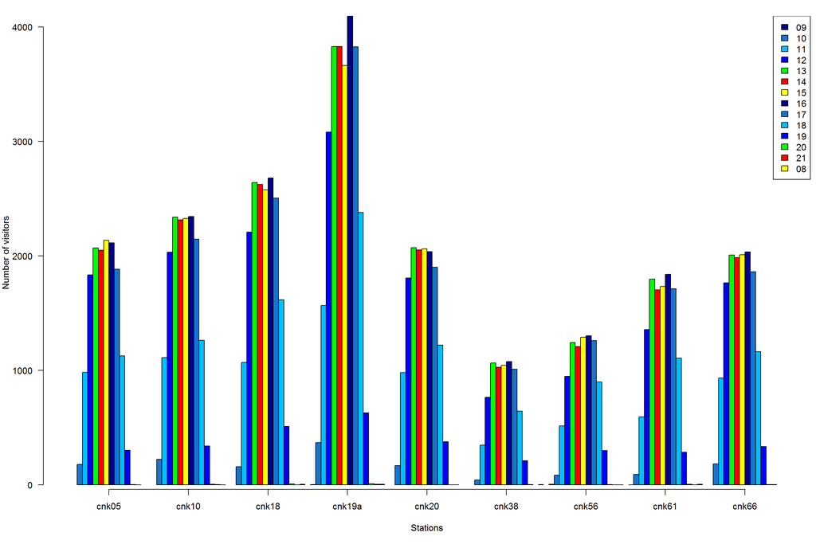

```r
par(mar = c(5, 4, 1.5, 0.5), ps = 12, cex  = 1, cex.main = 2, las = 1)
barplot(
  t(as.matrix(stationHourVisitorCountTab)),
  beside      = TRUE,
  xlab        = "Stations",
  ylab        = "Number of visitors",
  axes        = TRUE,
  axis.lty    = 1,
  col         = c("darkblue", "dodgerblue3", "deepskyblue1", "blue", "green", "red", "yellow"),
  panel.first =  abline(
    h    =  seq.int(25, 100, 25),
    col  =  "grey",
    lty  =  2
  )
)

legend("topright",
       legend = unique(hourStationData$hour),
       fill = c("darkblue", "dodgerblue3", "deepskyblue1", "blue", "green", "red", "yellow"))
```

```r
hourGeneralData = mergedData %>%
group_by(hour) %>%
summarise(avgTime = median(time),
          visitorCount = n())
hourGeneralData
```

```
## Source: local data frame [14 x 3]
##
##     hour avgTime visitorCount
##    (chr)   (dbl)        (int)
## 1     08      38            7
## 2     09      51         1492
## 3     10      59         8095
## 4     11      62        15795
## 5     12      66        19065
## 6     13      66        18793
## 7     14      67        18839
## 8     15      65        19521
## 9     16      63        18107
## 10    17      66        11419
## 11    18      72         3285
## 12    19      54           37
## 13    20      56           13
## 14    21      69           17
```

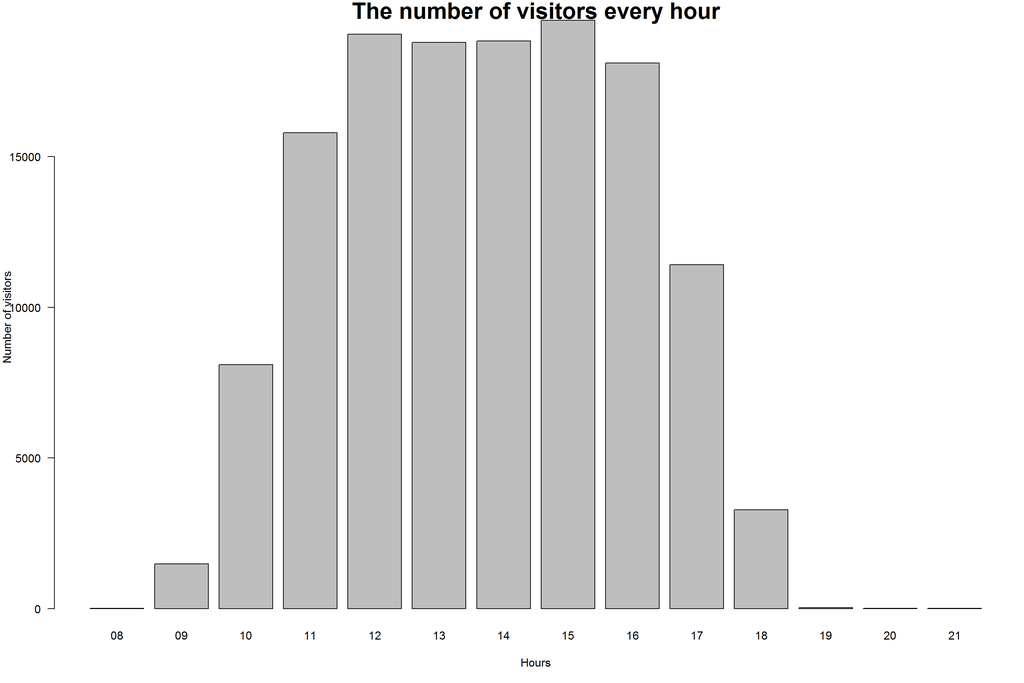

```r
# The number of visitors every hour
barplot(c(hourGeneralData$visitorCount), main="The number of visitors every hour", xlab="Hours",ylab = "Number of visitors",  names.arg=hourGeneralData$hour)
```

```r
# Distribution of the number of visitors per weekday
summary(hourGeneralData$visitorCount)
```

```
##    Min. 1st Qu.  Median    Mean 3rd Qu.    Max.
##     7.0   400.8  9757.0  9606.0 18620.0 19520.0
```

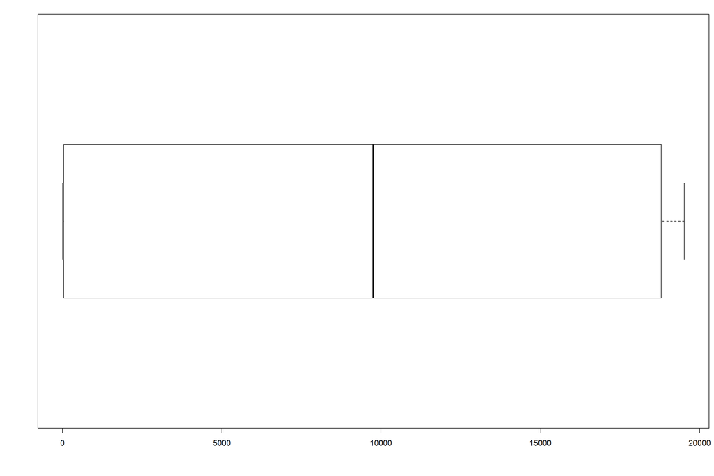

```r
# Boxplot of the number of visitors per weekday
boxplot(hourGeneralData$visitorCount, horizontal = TRUE)
```

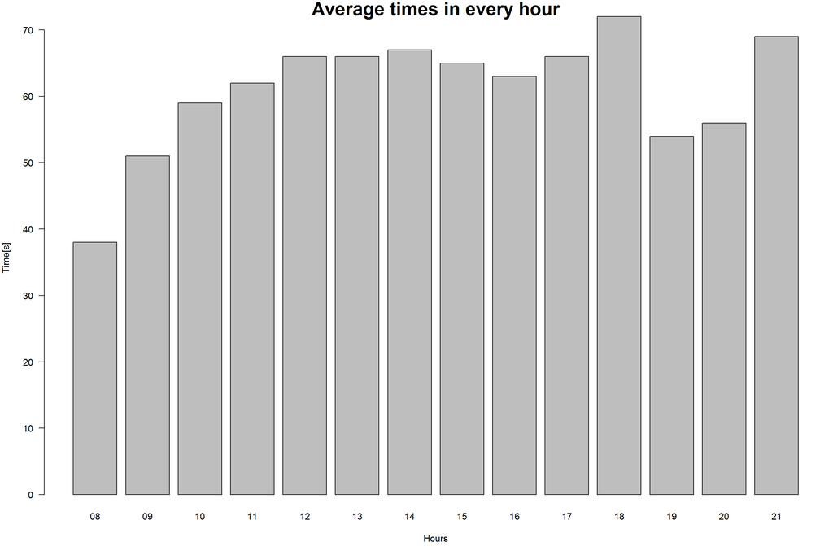

```r
# Average times in every hour
barplot(c(hourGeneralData$avgTime), main="Average times in every hour", xlab="Hours",ylab = "Time[s]", names.arg=hourGeneralData$hour)
```

```r
# Distribution of time per weekday
summary(hourGeneralData$avgTime)
```

```
##    Min. 1st Qu.  Median    Mean 3rd Qu.    Max.
##   38.00   56.75   64.00   61.00   66.00   72.00
```

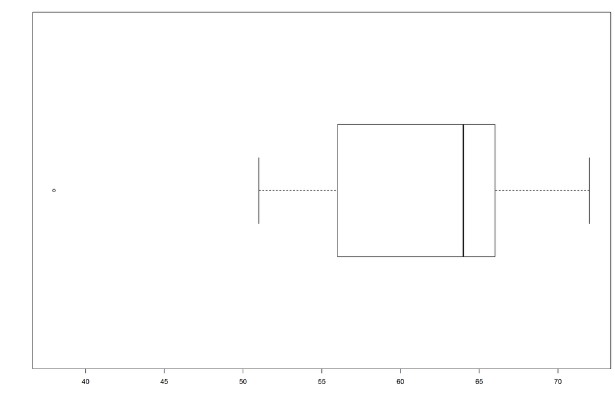

```r
# Boxplot of time per weekday
boxplot(hourGeneralData$avgTime, horizontal = TRUE)
```

## Weekday and hour

```r
stationData = mergedData %>%
group_by(station, weekday, hour) %>%
summarise(avgTime = median(time),
          visitorCount = n())
#stationData

# Distribution of time per station, weekday and hour
summary(stationData$avgTime)
```

```
##    Min. 1st Qu.  Median    Mean 3rd Qu.    Max.
##    4.00   54.00   69.00   76.43   94.00  275.00
```

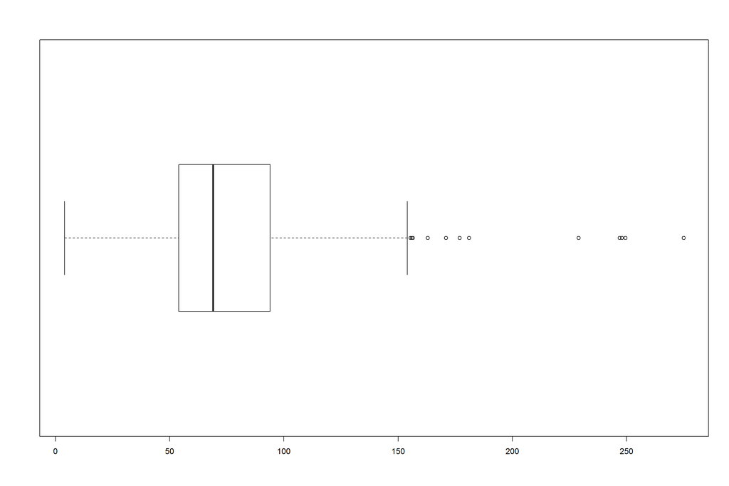

```r
# Boxplot of time per station, weekday and hour
boxplot(stationData$avgTime, horizontal = TRUE)
```

```r
# Distribution of the number of visitors per station, weekday and hour
summary(stationData$visitorCount)
```

```
##    Min. 1st Qu.  Median    Mean 3rd Qu.    Max.
##     1.0    82.0   230.0   234.7   345.0   782.0
```

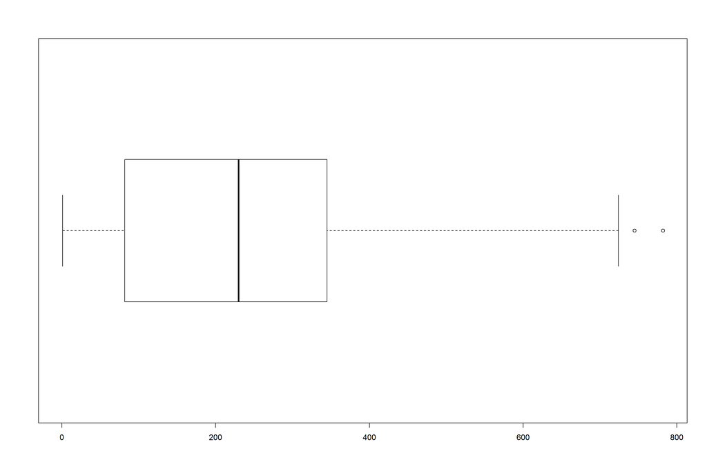

```r
# Boxplot of the number of visitors per station, weekday and hour
boxplot(stationData$visitorCount, horizontal = TRUE)
```

```r
generalData = mergedData %>%
group_by(weekday, hour) %>%
summarise(avgTime = median(time),
          visitorCount = n())
generalData = as.data.frame(generalData)

generalVisitorCountTab = cast(generalData, weekday ~ hour, value="visitorCount")
generalVisitorCountTab
```

```
##     weekday 08  09   10   11   12   13   14   15   16   17   18 19 20 21
## 1    Sunday NA  NA  346 1970 3003 3127 3194 3193 3122 2512 1294  9 NA NA
## 2    Monday NA   4    7    3   NA    1    4    1    1   NA   NA NA NA NA
## 3   Tuesday  2 212 1827 2850 3142 2961 3098 3317 2803 1405    8 NA NA NA
## 4 Wednesday  3 360 1694 2893 3223 3027 2879 3010 2706 1247   10  1 12 17
## 5  Thursday NA 430 1979 2960 3230 3070 3180 3243 2913 1415   14  2  1 NA
## 6    Friday  2 480 1829 3095 3409 3377 3204 3339 3177 1748   97  2 NA NA
## 7  Saturday NA   6  413 2024 3058 3230 3280 3418 3385 3092 1862 23 NA NA
```